# **Projet: Rapport automatisé Power BI & BD ORACLE en local**

### **Réalisation:Haral Valcourt**

### **Présentation du projet**

L’objectif principal de ce projet est de mettre en place un système de reporting automatisé et sécurisé en exploitant les fonctionnalités de Power BI Service couplées à une passerelle de données locale, afin de permettre la mise à jour régulière et transparente des rapports construits à partir d’une base de données Oracle hébergée localement. Cela implique :

- L'accès sécurisé aux données locales: Puisque la base de données Oracle se trouve dans l’environnement local (on-premises) et non dans le cloud, une passerelle de données est nécessaire. Cette passerelle permet à Power BI Service (dans le cloud) d'accéder de manière sécurisée aux données internes, sans les exposer directement à Internet.
- La publication des rapports dans Power BI Service : Les rapports sont conçus dans Power BI Desktop à partir de la table compte, puis publiés dans Power BI Service, la plateforme de partage et de collaboration de Microsoft.
- Le rafraîchissement automatique des jeux de données: Grâce à la passerelle, le dataset peut être mis à jour automatiquement selon une planification définie. Cela garantit que les utilisateurs ont toujours accès à des données à jour sans intervention manuelle.
- L'optimisation du processus métier: En automatisant ce processus,les analystes n'ont plus besoin de recharger les données manuellement ,les gestionnaires et décideurs disposeront de rapports actualisés en temps réel ou à fréquence régulière.

### **Environnement technique**

- Base de données: Oracle Database locale
- Outil de modélisation : Power BI Desktop (création et publication des rapports)
- Service cloud : Power BI Service (hébergement, rafraîchissement planifié, partage)
- Composant de connexion: Passerelle de données locale Power BI (GatewayInstall.exe)
- Automatisation : Power Automate pour déclenchements spécifiques

### **Jeu de données**

| Colonne | Type | Description |
| --- | --- | --- |
| NOCOMPTE | VARCHAR2(26) | Identifiant unique du compte |
| TYPE | NUMBER(38) | Type du compte(code numérique) |
| BRANCH | NUMBER(38) | Code Succursale/branche |
| SUCC | VARCHAR2(26) | Nom Succursale |
| ZONE | VARCHAR2(26) | Zone géographique |
| SEXE | VARCHAR2(26) | Sexe (Sexe du client) |
| DATENAIS | DATE | Date de naissance du client |
| BALANCE | NUMBER(38,2) | Solde du compte |
| STATUT | NUMBER(38) | Statut (code numérique) |
| NUMERO | NUMBER(38) | Numéro du client dans le système |
| TYPE_COMPTE | VARCHAR2(20) | Type de compte (libellé texte) |
| STATUT_COMPTE | VARCHAR2(20) | Statut classifié du compte |
| SEXE_CLIENT | VARCHAR2(10) | Sexe classifié du client |
| DATEOPEN | DATE | Date d’ouverture du compte |
| NATURE | VARCHAR2(15) | Nature du compte |

### **Étapes clés du projet**

- Connexion Power BI Desktop Oracle en mode import pour collecter les données
- Modélisation la table compte dans Power BI Desktop avec Power Query
- Création du rapport Power BI Desktop
- Installation et configuration de la passerelle Power BI sur site pour Oracle
- Publication du rapport sur Power BI Service dans un workspace
- Création d'un tableau de bord dans Power BI Service
- Création d'une application Power BI Service
- Configuration du rafraîchissement dans Power BI Service utilisant la passerelle
- Création d'un flux Power Automate pour déclencher le afraîchissement selon besoin
- Vérification que le refresh s’effectue sans erreur et que les données sont à jour

### **Connexion Power BI Desktop Oracle**

[figure not shown]

### **Modélisation la table compte dans Power BI Desktop avec Power Query**

#### **Création des colonnes calculées avec DAX**

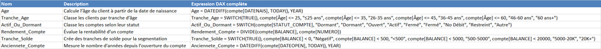

#### **Création des mesures avec DAX**

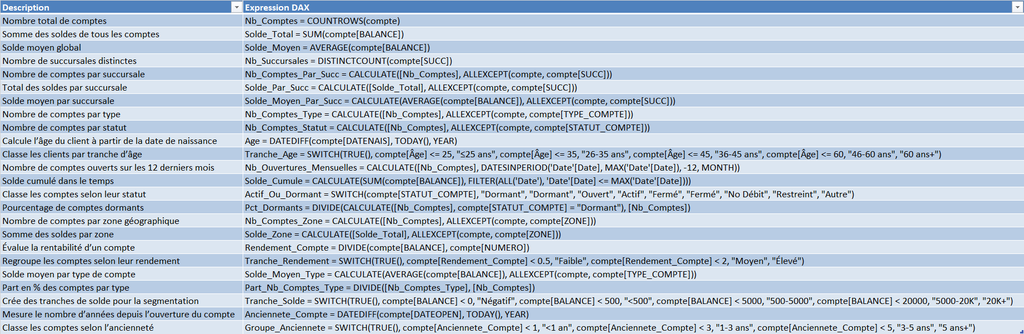

#### **Création de la table calculée Calendrier**

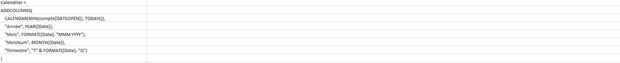

#### **Modélisation la table compte dans Power BI Desktop**

[figure not shown]

### **Création du rapport Power BI Desktop**

#### **Liste des pages**

Le rapport sera constitué des pages suivantes relatives à l'analyse d'un système bancaire:

- Vue d’ensemble (Dashboard exécutif)
- Analyse par Succursale
- Type & Statut de Compte
- Profil client (démographie)
- Évolution temporelle
- Comptes dormants et actifs
- Analyse par Zone géographique
- Rentabilité par compte
- Comparaison entre types de comptes
- Analyse par tranche de solde
- Fidélité / Ancienneté client
- Comptes à risque ou sensibles

#### **Objectif et visuels de chaque page**

- La page "Vue d’ensemble (Dashboard exécutif)" présente la synthèse globale de l’activité.
- La page "Analyse par Succursale" permet la comparaison des performances entre succursales.
- La page "Type & Statut de Compte" permet la répartition des comptes par type/statut.
- La page "Profil client (démographie)" permet une répartition par âge, sexe, tranche.
- La page "Évolution temporelle" permet un suivi mensuel et annuel des ouvertures et soldes.
- La page "Comptes dormants et actifs" permet la détection des comptes inactifs ou à solde nul.
- La page "Analyse par Zone géographique" permet la répartition par zone.
- La page "Comparaison entre types de comptes permet d'analyser l'efficacité des produits bancaires
- La page "Analyse par tranche de solde" permet de segmenter les comptes selon leur volume financier.
- La page "Fidélité / Ancienneté client" permet de mesurer la durée de relation client

### **Création de la page-Vue d’ensemble**

#### **Objectif**

Fournir une vue synthétique et instantanée de la situation globale des comptes bancaires, à travers des indicateurs clés (KPI), des tendances, et des répartitions globales. Cette page sert de point d’entrée pour la prise de décision rapide et le pilotage stratégique.

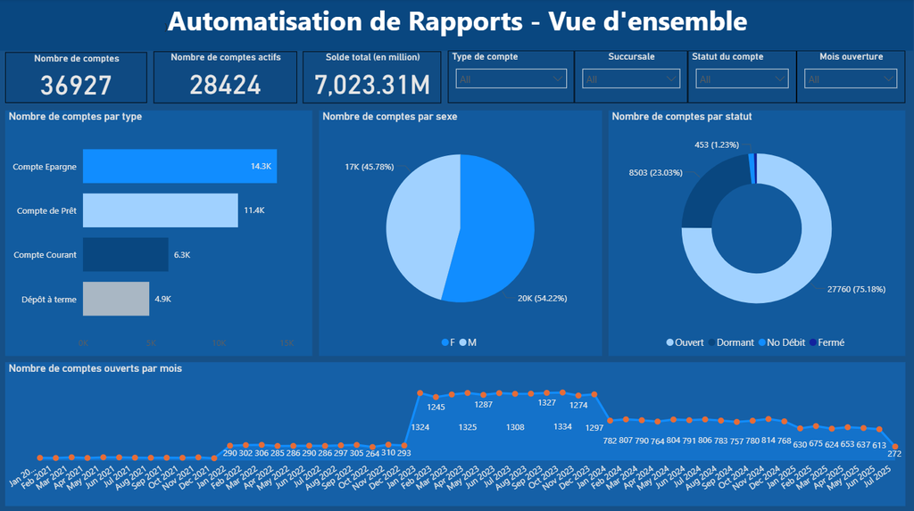

### **Création de la page - Analyse par Succursale**

#### **Objectif**

Évaluer la performance des succursales en termes de volume et de solde des comptes. Cette page permet d’identifier les succursales les plus performantes.

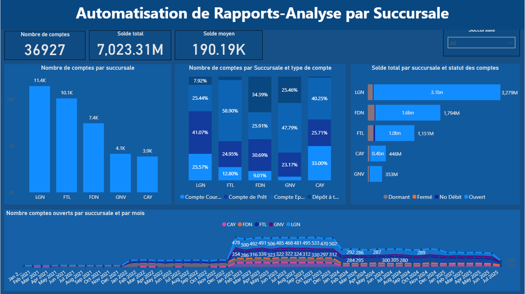

### **Création de la page - Type & Statut de Compte**

#### **Objectif**

Analyser la répartition des comptes selon leur type (Épargne, Courant, Prêt…) et leur statut (Ouvert, Fermé, Dormant, No Débit), afin d’évaluer la composition du portefeuille et détecter les tendances ou anomalies.

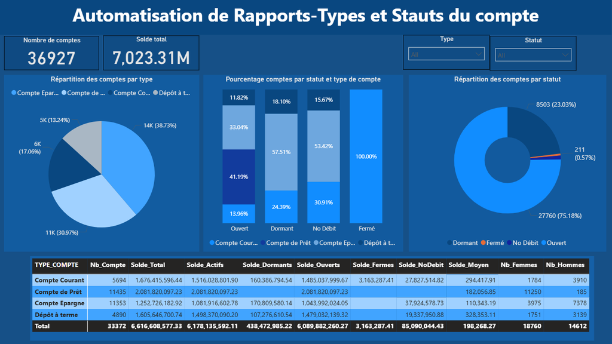

### **Création de la page - Profil client (Démographie)**

#### **Objectif**

Analyser la composition des clients selon leur sexe, tranche d’âge, nature juridique (Particulier vs Entreprise), et la répartition géographique, afin de mieux comprendre le profil des détenteurs de comptes.

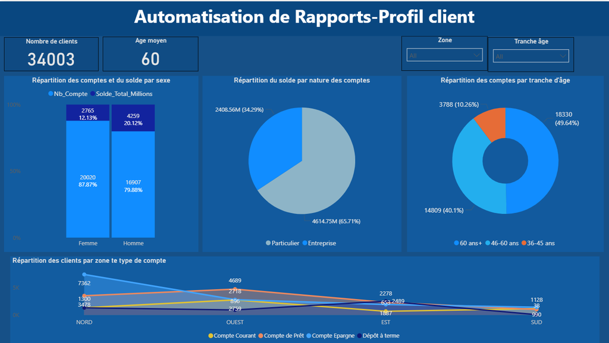

### **Création de la page - Évolution temporelle**

#### **Objectif**

Analyser l’évolution des comptes bancaires au fil du temps, en observant les ouvertures mensuelles, la croissance du solde global, la part des comptes dormants, et l’évolution par segment (type, statut, zone…).

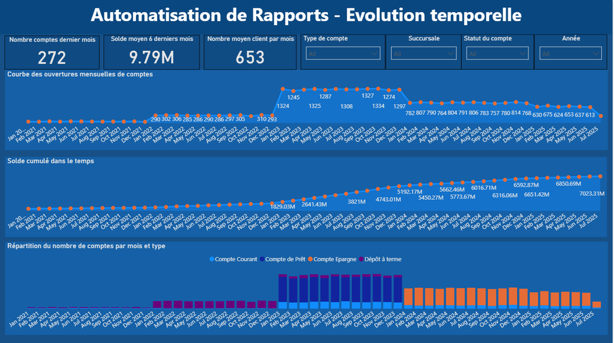

### **Création de la page - Comptes Dormants et Actifs**

#### **Objectif**

Analyser la répartition et l’évolution des comptes selon leur statut d’activité, identifier les zones à risque (dormance), comparer les performances des comptes actifs vs dormants.

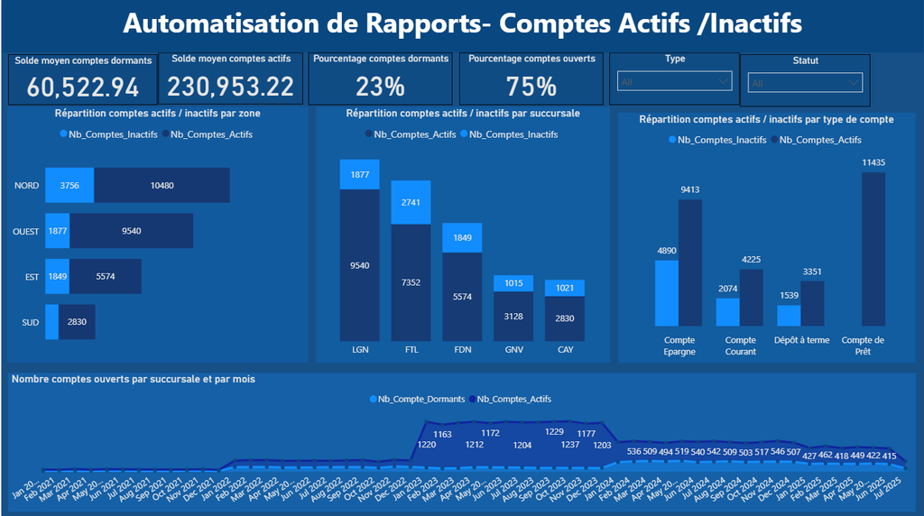

### **Création la page - Répartition géographique**

#### **Objectif**

Visualiser la répartition des comptes et des soldes sur le territoire (par ZONE ou SUCC), identifier les zones à fort potentiel ou à risque, et comparer les performances régionales.

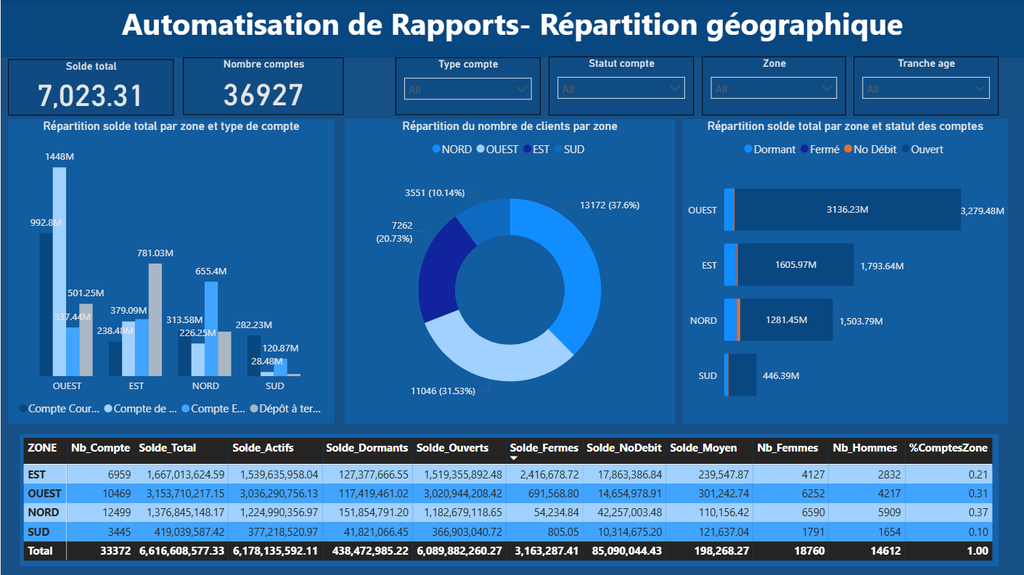

### **Création de la page - Fidélité et Ancienneté des comptes**

#### **Objectif**

Mesurer la durée de vie des comptes, leur ancienneté moyenne, détecter les comptes récents, stables ou à risque de fermeture.

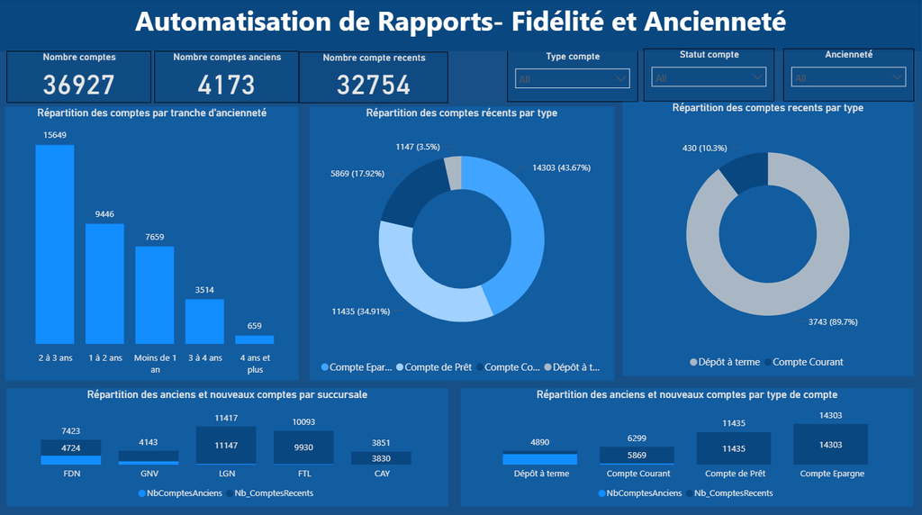

### **Création de la page - Comptes à risque ou sensibles**

#### **Objectif**

Identifier, catégoriser et surveiller les comptes à risque ou nécessitant une attention particulière, en fonction de critères métier (statut, solde faible, inactivité, restriction…).

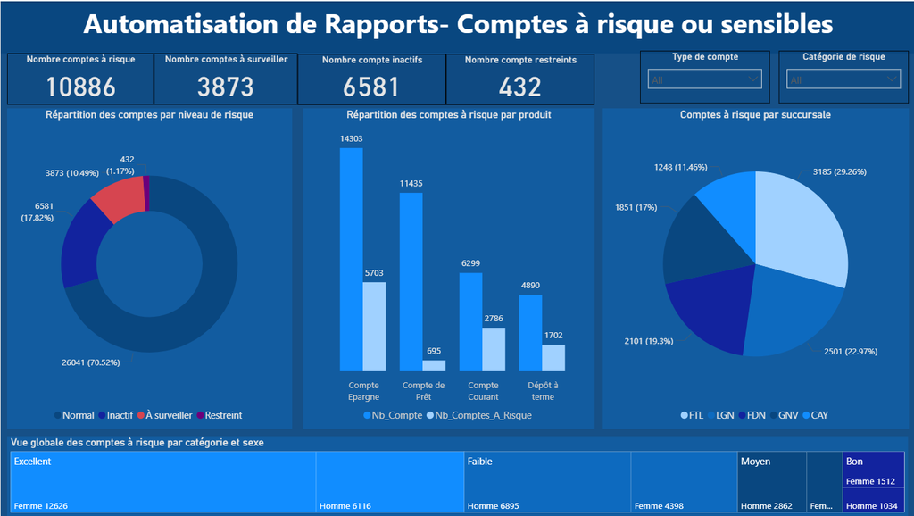

### **Création de la page - Performance par type de client (Particulier ou Entreprise)**

#### **Objectif**

Comparer les comportements et performances des clients Particuliers vs Entreprises, notamment en :Volume de comptes,Montants déposés et inactivité

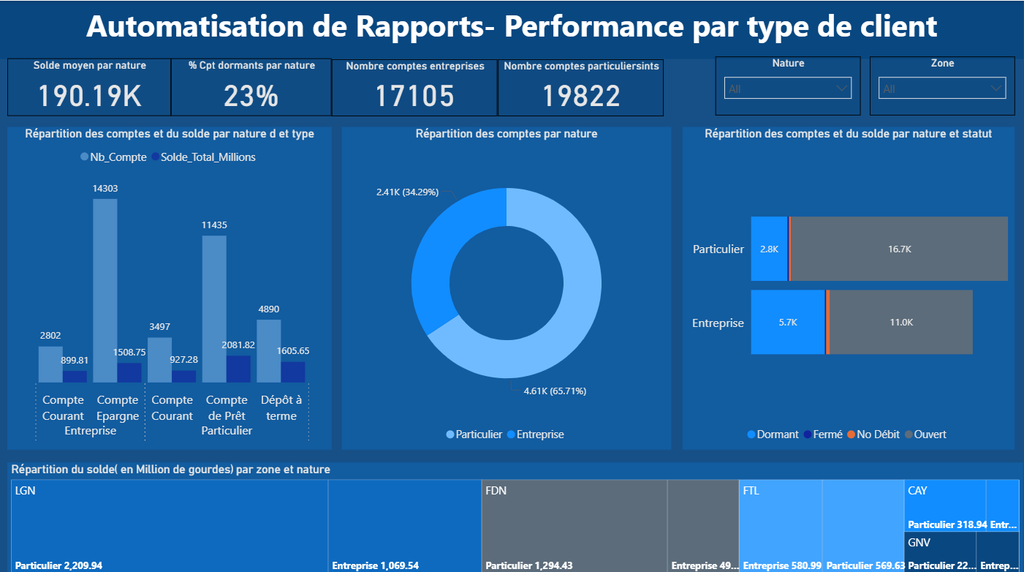

### **Création de la page - Analyse par tranche de solde**

#### **Objectif**

Etudier la répartition des comptes en fonction de leur encours, ce qui est essentiel pour la segmentation financière. Cette page permettra de segmenter les comptes selon leur solde pour identifier :

- Les comptes à faible encours
- Les comptes à fort potentiel
- Les zones ou succursales à valeur élevée ou faible

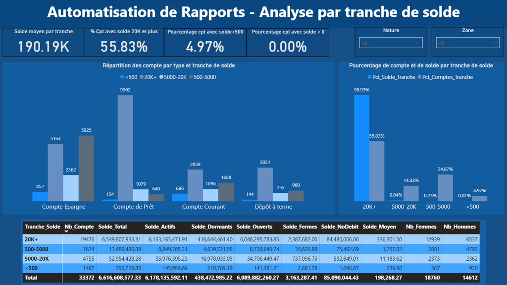

### **Publication du rapport sur Power BI Service dans un workspace**

Cette décision repose sur plusieurs objectifs :

- Offrir une meilleure lisibilité en simplifiant l’expérience utilisateur par thématique
- Renforcer le contrôle d’accès aux données en attribuant chaque rapport aux audiences concernées
- Faciliter la maintenance et les mises à jour, en permettant de modifier ou republier un module sans impacter les autres
- Personnaliser la diffusion des contenus selon les besoins de chaque département (direction, audit, finance, opérations, etc.)

L’ensemble des rapports a ensuite été intégré dans une application Power BI unique, structurée par audience. Cette application permet de distribuer efficacement les analyses à des profils variés, tout en garantissant une expérience cohérente et sécurisée.

[figure not shown]

### **Acces au workspace**

[figure not shown]

### **Configuration de la passerelle**

[figure not shown]

### **Utilisation de la passerelle**

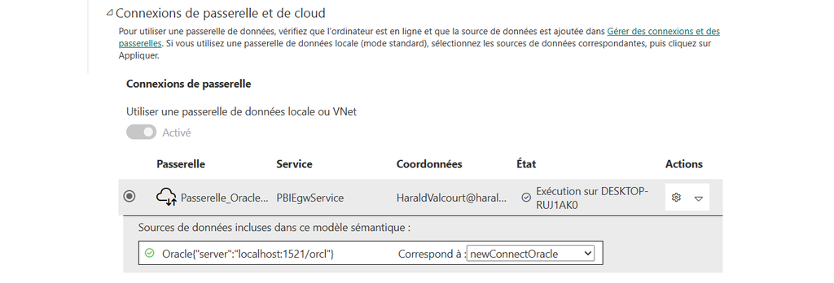

### **Réalisation des Dashboards Power BI Service**

Dans le cadre du projet, le choix a été fait de construire six dashboards thématiques dans Power BI Service, chacun étant conçu pour répondre aux besoins analytiques spécifiques d’une direction métier de la Banque.

Les KPI et visuels ont été regroupés selon une logique fonctionnelle, pour garantir une lisibilité optimale, une pertinence métier, ainsi qu’une distribution sécurisée et ciblée des contenus.

Cette approche permettra d’offrir à chaque direction un accès ciblé à des indicateurs stratégiques ou opérationnels, tout en assurant une gouvernance claire et une facilité de maintenance des rapports. Les dashboards seront intégrés dans une application Power BI structurée par audience, garantissant une expérience utilisateur fluide, sécurisée et adaptée aux besoins métiers.

### **Dashboard – Vue d’Ensemble**

#### **Destinataire**

Comité de direction,hauts responsables

#### **Objectif :**

Offrir aux membres du comité de direction une vue consolidée et synthétique de l’état global du portefeuille de comptes, en facilitant le pilotage stratégique et l’identification rapide des tendances clés (croissance, équilibre, répartition). il est constitué des visuels suivants:

- Nombre de comptes par succursale et type de compte
- Pourcentage de comptes par statut et type de compte
- Répartition des comptes actifs/inactifs par type de compte
- Répartition du solde total par zone et statut
- Répartition du solde total par zone et type de compte
- Répartition des comptes et du solde par nature et type de compte

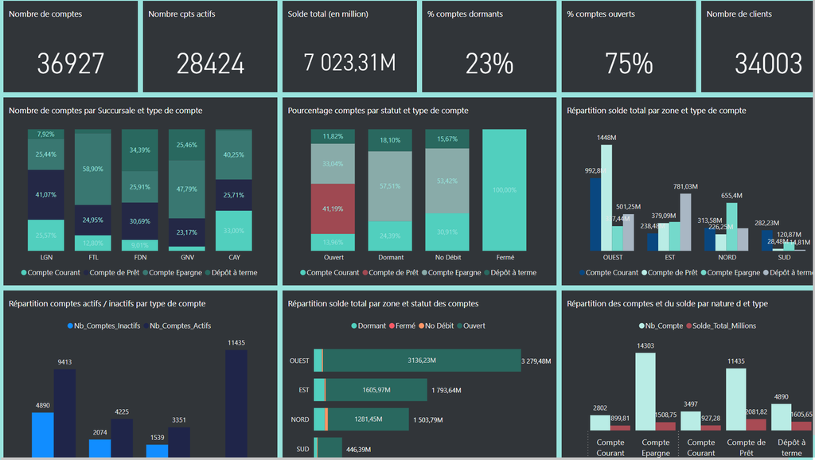

[figure not shown]

### **Dashboard – Analyse par Succursale**

#### **Destinataire**

Direction du Réseau

#### **Objectif :**

Permettre à la Direction du Réseau de suivre les performances des succursales, de comparer les implantations entre elles, d’analyser l’évolution des ouvertures et d’identifier les zones à fort ou faible dynamisme commercial. il est constitué des visuels suivants:

- Répartition des comptes actifs/inactifs par succursale
- Répartition des comptes nouveaux/anciens par succursale
- Nombre total de comptes par succursale
- Évolution mensuelle des ouvertures par succursale

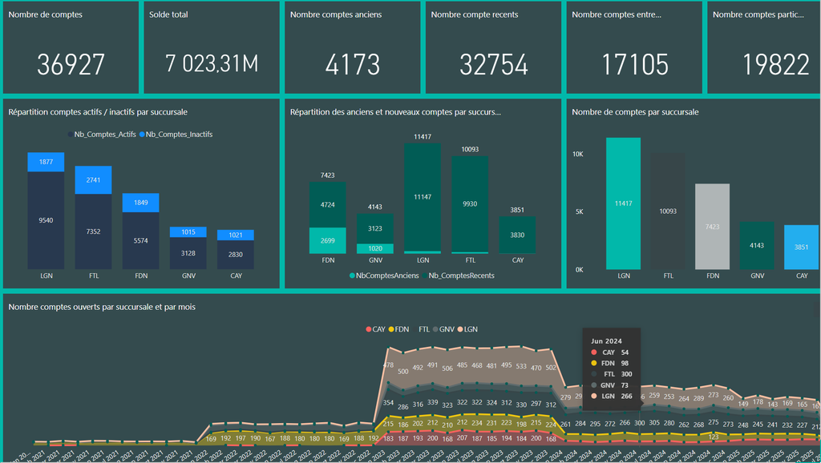

[figure not shown]

### **Dashboard – Type et Statut de Compte**

#### **Destinataire**

Direction des Opérations

#### **Objectif :**

Fournir à la Direction des Opérations une analyse détaillée de la structure des comptes selon leur type et leur statut, afin d’optimiser la gestion opérationnelle, d’anticiper les besoins, et de détecter les segments dormants ou en croissance etc. il est constitué des visuels suivants:

- Répartition des comptes par type
- Répartition par type et tranche de balance
- Répartition des comptes par statut
- Répartition des comptes nouveaux/anciens par type de compte
- Répartition des comptes et du solde par nature et statut
- Répartition par tranche de solde
- Nombre de comptes ouverts par mois et par type

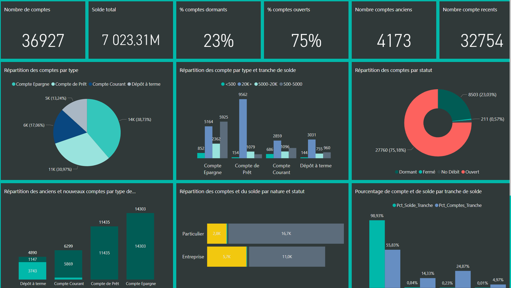

[figure not shown]

### **Dashboard – Marketing**

#### **Destinataire**

Direction du Marketing

#### **Objectif :**

Mettre à disposition de la Direction Marketing une vision approfondie du profil des clients, en termes de comportement, démographie et géographie, pour orienter les actions de ciblage, les campagnes promotionnelles et les stratégies de segmentation. il est constitué des visuels suivants:

- Répartition des comptes par solde et sexe
- Répartition des comptes par tranche d’âge
- Répartition du solde total par zone et statut
- Répartition du nombre de clients par zone
- Répartition des comptes nouveaux/anciens par succursale
- Répartition du solde par zone et nature
- Répartition des clients par zone et type de compte

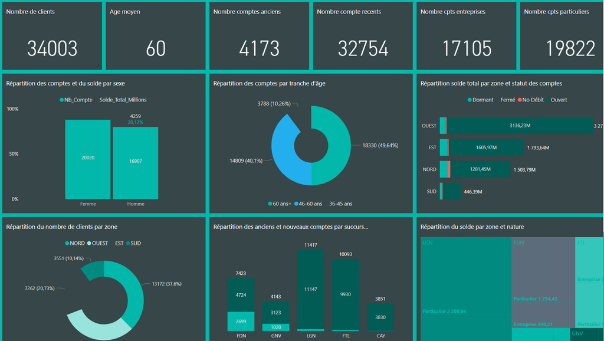

[figure not shown]

### **Dashboard – Audit & Risque**

#### **Destinataire**

Direction Audit et Risques

#### **Objectif :**

Aider la Direction Audit et Risques à identifier, classifier et surveiller les comptes sensibles ou à risque, en croisant les indicateurs de statut, produit, zone et catégorie client, afin d’améliorer le contrôle interne et les dispositifs de mitigation. il est constitué des visuels suivants:

- Répartition des comptes par niveau de risque
- Comptes à risque par produit
- Comptes à risque par succursale
- Vue globale par catégorie de risque et sexe du client
- Répartition des comptes par statut
- Pourcentage de comptes par statut et type

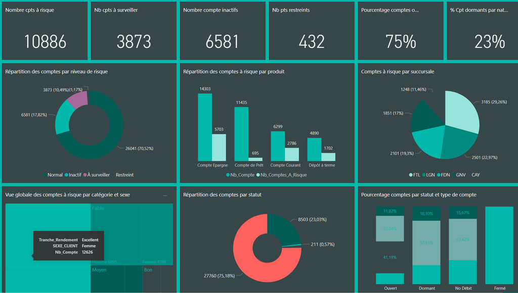

[figure not shown]

### **Dashboard – Finance**

#### **Destinataire**

Direction Financière

#### **Objectif :**

Fournir à la Direction Financière une lecture consolidée de la répartition des soldes, de leur évolution dans le temps et de leur typologie, pour assurer un suivi rigoureux des encours, optimiser l’allocation des ressources et alimenter les reporting financiers. il est constitué des visuels suivants:

- Répartition du solde total par zone et type de compte
- Répartition du solde total par zone et statut
- Répartition du solde total par zone et nature des comptes
- Suivi du solde cumulé dans le temps

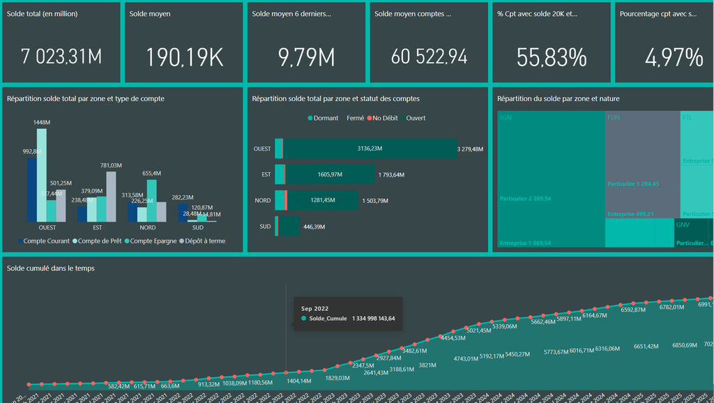

[figure not shown]

### **Création d'une application Power BI**

#### **Definition des audiences**

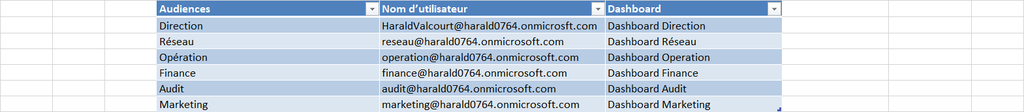

#### **Création des comptes de test dans Microsoft 365**

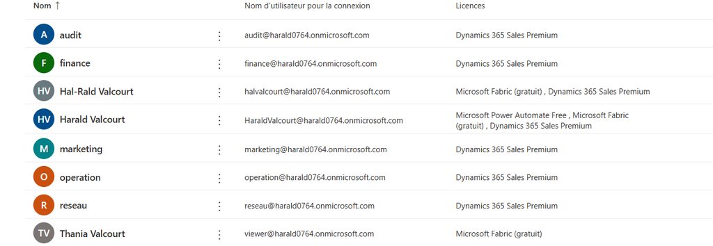

#### **Création des audiences**

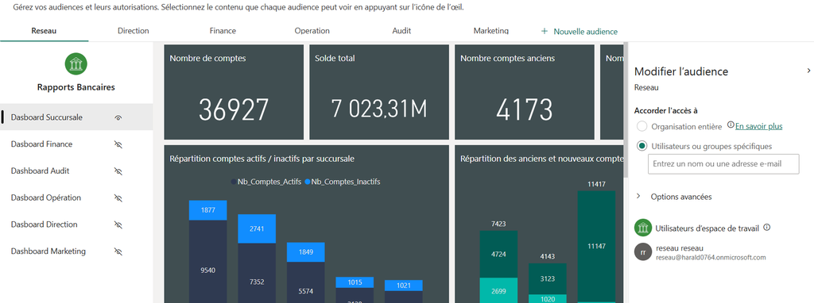

#### **Ecran de l'application Power BI Service**

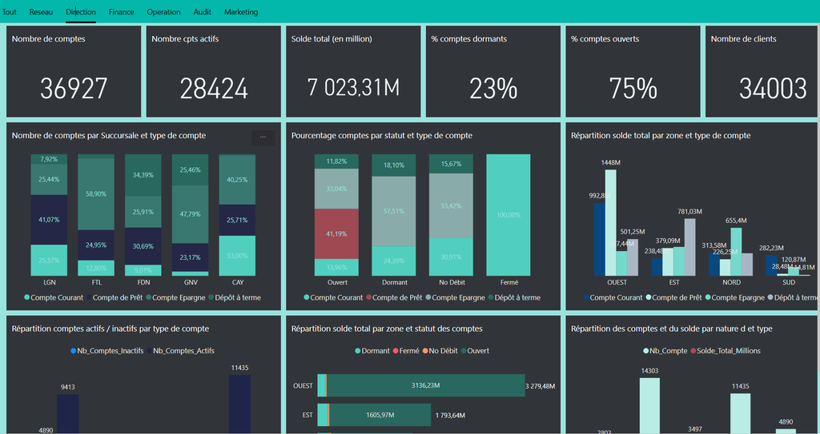

#### **Acces à l'application Power BI Service par l'utilisateur "Audit"**

[figure not shown]

### **Rafraîchissement automatique des jeux de données**

### **Actualisation planifiée native – Power BI Service**

[figure not shown]

#### **Verification de l'actualisation planifiée réussie**

[figure not shown]

### **Actualisation automatisée avancée – Power Automate**

#### **Création du flux pour l'actualisation automatique dans Power Automate**

[figure not shown]

[figure not shown]

#### **Verification de l'actualisation planifiée réussie**

[figure not shown]